# 02_AssignASVs.Rmd

Emily Wahly

April 22, 2026

# Goals

1. Infer an error model for in the filtered sequences, separately on forward and reverse reads.
2. Assign ASVs on both forward and reverse reads separately by applying the error model.
3. Merge forward and reverse ASVs into “contiguous ASVs”.
4. Generate the first draft of ASV count table.
5. Quality Trimming of ASV lengths.
6. Remove chimeras.
7. Assign Taxonomy with Silva Database.
8. Write out relevant files: `asv_table`, `asvs_fasta`, `tax_table`, and `sample_data`.
9. Create a **S4** R data object, which in this case is known as a phyloseq, object from the `asv_table`, `tax_table`, and metadata. This will give us one data object to work with moving forward. :)

## Input

1. Filtered fastq files generated from `01_QualityTrimming.Rmd`.
2. Sample Name vector.

## Output

1. ASV Count Table: `asv_table` (with and without sequence names)
2. ASV fasta file: `asvs_fasta` for building a phylogenetic tree at a later step.
3. Taxonomy Table `tax_table`
4. Sample Information: `sample_data` track the reads lots throughout DADA2 workflow.

# Set up the Environment

## Set Seed & Threads

We need to be mindful of others when we are using the server. We learned in this lesson that we can use `top` and `htop` in the shell to see how many users are currently on the server. So, if you’re working through something outside of class, it’s ok to increase the number of threads. And, it will make everything go faster!

Then, when we have a `multithread` parameter, we can set it to be `multithread = n_threads`. If we notice more people on the server, we can modify the n_threads in this one location.

```r
# Set the seed for reproducibility
set.seed(238428)

# Let's make a parameter to set the number of threads
n_threads = 30
```

## Timing of this script

Let’s record how long this file took to run on the class server, which we will record at the end of the script.

```r
# What time did we start running this script?
start_time <- Sys.time()
```

## Load Packages

```r
# Efficient package loading with pacman
pacman::p_load(tidyverse, devtools, dada2, phyloseq,
               patchwork, DT, install = FALSE)
```

#Load filtered fastq files

```r
# Place filtered seq files into a variable
filtered_fastqs_path <- "/local/workdir/erw98/Brassica_Growth_2026/data/01_Quality_Trimming/filtered_fastqs"
# Create Forward vector
filtered_forward_reads <-
  list.files(filtered_fastqs_path, pattern = "R1_filtered.fastq.gz",
             full.names = TRUE)
# Reverse vector
filtered_reverse_reads <-
    list.files(filtered_fastqs_path, pattern = "R2_filtered.fastq.gz",
             full.names = TRUE)

# Check
filtered_forward_reads[1:5]
```

```
## [1] "/local/workdir/erw98/Brassica_Growth_2026/data/01_Quality_Trimming/filtered_fastqs/SRR11917047_R1_filtered.fastq.gz"
## [2] "/local/workdir/erw98/Brassica_Growth_2026/data/01_Quality_Trimming/filtered_fastqs/SRR11917048_R1_filtered.fastq.gz"
## [3] "/local/workdir/erw98/Brassica_Growth_2026/data/01_Quality_Trimming/filtered_fastqs/SRR11917049_R1_filtered.fastq.gz"
## [4] "/local/workdir/erw98/Brassica_Growth_2026/data/01_Quality_Trimming/filtered_fastqs/SRR11917050_R1_filtered.fastq.gz"
## [5] "/local/workdir/erw98/Brassica_Growth_2026/data/01_Quality_Trimming/filtered_fastqs/SRR11917051_R1_filtered.fastq.gz"
```

```r
filtered_reverse_reads[1:5]
```

```
## [1] "/local/workdir/erw98/Brassica_Growth_2026/data/01_Quality_Trimming/filtered_fastqs/SRR11917047_R2_filtered.fastq.gz"
## [2] "/local/workdir/erw98/Brassica_Growth_2026/data/01_Quality_Trimming/filtered_fastqs/SRR11917048_R2_filtered.fastq.gz"
## [3] "/local/workdir/erw98/Brassica_Growth_2026/data/01_Quality_Trimming/filtered_fastqs/SRR11917049_R2_filtered.fastq.gz"
## [4] "/local/workdir/erw98/Brassica_Growth_2026/data/01_Quality_Trimming/filtered_fastqs/SRR11917050_R2_filtered.fastq.gz"
## [5] "/local/workdir/erw98/Brassica_Growth_2026/data/01_Quality_Trimming/filtered_fastqs/SRR11917051_R2_filtered.fastq.gz"
```

```r
# Create vector of sample names from the filenames
sample_names <- sapply(strsplit(basename(filtered_forward_reads), "_"), `[`,1)

# Intuition Check
head(sample_names)
```

```
## [1] "SRR11917047" "SRR11917048" "SRR11917049" "SRR11917050" "SRR11917051"
## [6] "SRR11917052"
```

sample names #Learn the Errors MiSeq Runs: 40 Phred Scores

```r
# Forward Reads
error_forward_reads <-
  learnErrors(filtered_forward_reads, multithread = n_threads)
```

```
## 100697500 total bases in 402790 reads from 37 samples will be used for learning the error rates.
```

```r
#81 samples
# Forward Error Plot
forward_error_plot <-
  plotErrors(error_forward_reads, nominalQ = TRUE) +
  labs(title = "Forward Reads: Error Model")

# Reverse Reads
error_reverse_reads <-
  learnErrors(filtered_reverse_reads, multithread = n_threads)
```

```
## 101504550 total bases in 580026 reads from 54 samples will be used for learning the error rates.
```

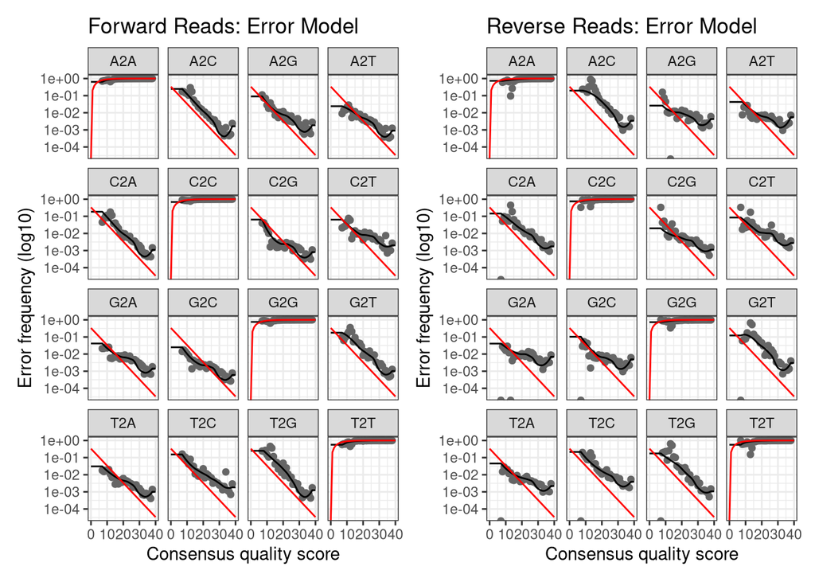

```r
# Reverse Error Plot
reverse_error_plot <-
  plotErrors(error_reverse_reads, nominalQ = TRUE) +
  labs(title = "Reverse Reads: Error Model")

# Look at the plots together
forward_error_plot + reverse_error_plot
```

#Merge Forward and Reverse ASVs

```r
merged_ASVs <-
  mergePairs(dada_forward, filtered_forward_reads,
             dada_reverse, filtered_reverse_reads,
             verbose = TRUE)
```

```
## 13869 paired-reads (in 318 unique pairings) successfully merged out of 14228 (in 447 pairings) input.
```

```
## 31235 paired-reads (in 605 unique pairings) successfully merged out of 32864 (in 1016 pairings) input.
```

```
## 10833 paired-reads (in 303 unique pairings) successfully merged out of 11258 (in 411 pairings) input.
```

```
## 8934 paired-reads (in 430 unique pairings) successfully merged out of 9762 (in 691 pairings) input.
```

```
## 15047 paired-reads (in 456 unique pairings) successfully merged out of 17344 (in 801 pairings) input.
```

```
## 4339 paired-reads (in 104 unique pairings) successfully merged out of 4501 (in 108 pairings) input.
```

```
## 7183 paired-reads (in 519 unique pairings) successfully merged out of 7457 (in 612 pairings) input.
```

```
## 5520 paired-reads (in 345 unique pairings) successfully merged out of 5752 (in 425 pairings) input.
```

```
## 2436 paired-reads (in 106 unique pairings) successfully merged out of 2529 (in 133 pairings) input.
```

```
## 8720 paired-reads (in 121 unique pairings) successfully merged out of 9220 (in 282 pairings) input.
```

```
## 490 paired-reads (in 24 unique pairings) successfully merged out of 582 (in 30 pairings) input.
```

```
## 3481 paired-reads (in 97 unique pairings) successfully merged out of 3610 (in 156 pairings) input.
```

```
## 1229 paired-reads (in 82 unique pairings) successfully merged out of 1312 (in 94 pairings) input.
```

```
## 8782 paired-reads (in 368 unique pairings) successfully merged out of 9835 (in 549 pairings) input.
```

```
## 10453 paired-reads (in 312 unique pairings) successfully merged out of 11356 (in 468 pairings) input.
```

```
## 5408 paired-reads (in 646 unique pairings) successfully merged out of 6651 (in 715 pairings) input.
```

```
## 7211 paired-reads (in 488 unique pairings) successfully merged out of 8895 (in 781 pairings) input.
```

```
## 14464 paired-reads (in 1041 unique pairings) successfully merged out of 16355 (in 1172 pairings) input.
```

```
## 78 paired-reads (in 3 unique pairings) successfully merged out of 92 (in 6 pairings) input.
```

```
## 7163 paired-reads (in 444 unique pairings) successfully merged out of 7330 (in 525 pairings) input.
```

```
## 5514 paired-reads (in 457 unique pairings) successfully merged out of 7653 (in 779 pairings) input.
```

```
## 12146 paired-reads (in 596 unique pairings) successfully merged out of 14038 (in 1135 pairings) input.
```

```
## 13345 paired-reads (in 218 unique pairings) successfully merged out of 14124 (in 340 pairings) input.
```

```
## 37057 paired-reads (in 406 unique pairings) successfully merged out of 37981 (in 601 pairings) input.
```

```
## 9155 paired-reads (in 215 unique pairings) successfully merged out of 9654 (in 264 pairings) input.
```

```
## 12898 paired-reads (in 329 unique pairings) successfully merged out of 13493 (in 556 pairings) input.
```

```
## 7433 paired-reads (in 952 unique pairings) successfully merged out of 8246 (in 1015 pairings) input.
```

```
## 0 paired-reads (in 0 unique pairings) successfully merged out of 2 (in 1 pairings) input.
```

```
## 6421 paired-reads (in 417 unique pairings) successfully merged out of 6808 (in 552 pairings) input.
```

```
## 26396 paired-reads (in 554 unique pairings) successfully merged out of 26997 (in 635 pairings) input.
```

```
## 1581 paired-reads (in 85 unique pairings) successfully merged out of 1655 (in 90 pairings) input.
```

```
## 4747 paired-reads (in 135 unique pairings) successfully merged out of 4923 (in 199 pairings) input.
```

```
## 7890 paired-reads (in 131 unique pairings) successfully merged out of 8179 (in 202 pairings) input.
```

```
## 5189 paired-reads (in 196 unique pairings) successfully merged out of 5511 (in 290 pairings) input.
```

```
## 10871 paired-reads (in 539 unique pairings) successfully merged out of 11367 (in 701 pairings) input.
```

```
## 3482 paired-reads (in 119 unique pairings) successfully merged out of 3866 (in 159 pairings) input.
```

```
## 30824 paired-reads (in 1644 unique pairings) successfully merged out of 32081 (in 2090 pairings) input.
```

```
## 7830 paired-reads (in 344 unique pairings) successfully merged out of 8321 (in 458 pairings) input.
```

```
## 7464 paired-reads (in 100 unique pairings) successfully merged out of 7464 (in 100 pairings) input.
```

```
## 14199 paired-reads (in 707 unique pairings) successfully merged out of 16023 (in 1079 pairings) input.
```

```
## 9926 paired-reads (in 1006 unique pairings) successfully merged out of 10683 (in 1080 pairings) input.
```

```
## 4919 paired-reads (in 517 unique pairings) successfully merged out of 7021 (in 720 pairings) input.
```

```
## 10958 paired-reads (in 311 unique pairings) successfully merged out of 11139 (in 361 pairings) input.
```

```
## 4914 paired-reads (in 102 unique pairings) successfully merged out of 4990 (in 111 pairings) input.
```

```
## 5878 paired-reads (in 587 unique pairings) successfully merged out of 6252 (in 692 pairings) input.
```

```
## No paired-reads (in ZERO unique pairings) successfully merged out of 3 pairings) input.
```

```
## 6032 paired-reads (in 338 unique pairings) successfully merged out of 7553 (in 533 pairings) input.
```

```
## 3152 paired-reads (in 365 unique pairings) successfully merged out of 3421 (in 403 pairings) input.
```

```
## 3741 paired-reads (in 580 unique pairings) successfully merged out of 5103 (in 742 pairings) input.
```

```
## 15946 paired-reads (in 203 unique pairings) successfully merged out of 16432 (in 357 pairings) input.
```

```
## 9536 paired-reads (in 569 unique pairings) successfully merged out of 10058 (in 726 pairings) input.
```

```
## 15421 paired-reads (in 357 unique pairings) successfully merged out of 16310 (in 547 pairings) input.
```

```
## 25533 paired-reads (in 256 unique pairings) successfully merged out of 26114 (in 347 pairings) input.
```

```
## 11663 paired-reads (in 325 unique pairings) successfully merged out of 12276 (in 526 pairings) input.
```

```
## 7497 paired-reads (in 125 unique pairings) successfully merged out of 7559 (in 140 pairings) input.
```

```
## 9957 paired-reads (in 772 unique pairings) successfully merged out of 10757 (in 1014 pairings) input.
```

```
## 63511 paired-reads (in 1049 unique pairings) successfully merged out of 65244 (in 1452 pairings) input.
```

```
## 1103 paired-reads (in 57 unique pairings) successfully merged out of 1135 (in 70 pairings) input.
```

```
## 6802 paired-reads (in 307 unique pairings) successfully merged out of 7036 (in 434 pairings) input.
```

```
## 59 paired-reads (in 2 unique pairings) successfully merged out of 107 (in 6 pairings) input.
```

```
## 2483 paired-reads (in 118 unique pairings) successfully merged out of 2899 (in 179 pairings) input.
```

```
## 14555 paired-reads (in 661 unique pairings) successfully merged out of 14992 (in 811 pairings) input.
```

```
## 8936 paired-reads (in 124 unique pairings) successfully merged out of 9096 (in 138 pairings) input.
```

```
## 581 paired-reads (in 16 unique pairings) successfully merged out of 604 (in 19 pairings) input.
```

```
## 6480 paired-reads (in 472 unique pairings) successfully merged out of 7504 (in 639 pairings) input.
```

```
## 9364 paired-reads (in 400 unique pairings) successfully merged out of 9921 (in 642 pairings) input.
```

```
## 10474 paired-reads (in 439 unique pairings) successfully merged out of 11501 (in 622 pairings) input.
```

```
## 20252 paired-reads (in 1224 unique pairings) successfully merged out of 22672 (in 1789 pairings) input.
```

```
## 4247 paired-reads (in 399 unique pairings) successfully merged out of 4760 (in 424 pairings) input.
```

```
## 5210 paired-reads (in 697 unique pairings) successfully merged out of 5566 (in 752 pairings) input.
```

```
## 9335 paired-reads (in 851 unique pairings) successfully merged out of 9932 (in 936 pairings) input.
```

```
## 5792 paired-reads (in 226 unique pairings) successfully merged out of 5821 (in 248 pairings) input.
```

```
## 6288 paired-reads (in 494 unique pairings) successfully merged out of 6772 (in 526 pairings) input.
```

```
## 8271 paired-reads (in 386 unique pairings) successfully merged out of 8574 (in 471 pairings) input.
```

```
## 7848 paired-reads (in 164 unique pairings) successfully merged out of 7943 (in 188 pairings) input.
```

```
## 17457 paired-reads (in 986 unique pairings) successfully merged out of 18263 (in 1080 pairings) input.
```

```
## No paired-reads (in ZERO unique pairings) successfully merged out of 4 pairings) input.
```

```
## 1502 paired-reads (in 301 unique pairings) successfully merged out of 1853 (in 344 pairings) input.
```

```
## 16889 paired-reads (in 586 unique pairings) successfully merged out of 17329 (in 753 pairings) input.
```

```
## 6146 paired-reads (in 213 unique pairings) successfully merged out of 6351 (in 246 pairings) input.
```

```
## 10225 paired-reads (in 241 unique pairings) successfully merged out of 11148 (in 493 pairings) input.
```

```
## 9926 paired-reads (in 142 unique pairings) successfully merged out of 10317 (in 257 pairings) input.
```

```
## 10026 paired-reads (in 201 unique pairings) successfully merged out of 10878 (in 470 pairings) input.
```

```
## 7731 paired-reads (in 872 unique pairings) successfully merged out of 9057 (in 999 pairings) input.
```

```
## 14265 paired-reads (in 427 unique pairings) successfully merged out of 15832 (in 836 pairings) input.
```

```
## 81 paired-reads (in 5 unique pairings) successfully merged out of 81 (in 5 pairings) input.
```

```
## 21392 paired-reads (in 1039 unique pairings) successfully merged out of 22033 (in 1262 pairings) input.
```

```
## 1691 paired-reads (in 84 unique pairings) successfully merged out of 1803 (in 130 pairings) input.
```

```
## 4918 paired-reads (in 118 unique pairings) successfully merged out of 5154 (in 209 pairings) input.
```

```
## 4876 paired-reads (in 122 unique pairings) successfully merged out of 5392 (in 261 pairings) input.
```

```
## 9808 paired-reads (in 443 unique pairings) successfully merged out of 10028 (in 505 pairings) input.
```

```
## 11172 paired-reads (in 289 unique pairings) successfully merged out of 11703 (in 448 pairings) input.
```

```
## 13952 paired-reads (in 295 unique pairings) successfully merged out of 14731 (in 466 pairings) input.
```

```
## 7969 paired-reads (in 152 unique pairings) successfully merged out of 8128 (in 178 pairings) input.
```

```
## 0 paired-reads (in 0 unique pairings) successfully merged out of 2 (in 1 pairings) input.
```

```
## 9551 paired-reads (in 403 unique pairings) successfully merged out of 11665 (in 749 pairings) input.
```

```
## 7158 paired-reads (in 285 unique pairings) successfully merged out of 7598 (in 344 pairings) input.
```

```
## 6183 paired-reads (in 498 unique pairings) successfully merged out of 9197 (in 792 pairings) input.
```

```
## 11781 paired-reads (in 227 unique pairings) successfully merged out of 12349 (in 242 pairings) input.
```

```
## 4402 paired-reads (in 647 unique pairings) successfully merged out of 6185 (in 776 pairings) input.
```

```
## 10483 paired-reads (in 530 unique pairings) successfully merged out of 10857 (in 645 pairings) input.
```

```
## 5630 paired-reads (in 132 unique pairings) successfully merged out of 5655 (in 143 pairings) input.
```

```
## 3345 paired-reads (in 152 unique pairings) successfully merged out of 5338 (in 333 pairings) input.
```

```
## 8298 paired-reads (in 441 unique pairings) successfully merged out of 8624 (in 554 pairings) input.
```

```
## 65 paired-reads (in 2 unique pairings) successfully merged out of 66 (in 3 pairings) input.
```

```
## 2316 paired-reads (in 193 unique pairings) successfully merged out of 4028 (in 383 pairings) input.
```

```
## 7189 paired-reads (in 858 unique pairings) successfully merged out of 8132 (in 961 pairings) input.
```

```
## 7887 paired-reads (in 565 unique pairings) successfully merged out of 8989 (in 736 pairings) input.
```

```
## 16783 paired-reads (in 339 unique pairings) successfully merged out of 17024 (in 438 pairings) input.
```

```
## 13903 paired-reads (in 421 unique pairings) successfully merged out of 15508 (in 684 pairings) input.
```

```
## 11704 paired-reads (in 1013 unique pairings) successfully merged out of 12877 (in 1270 pairings) input.
```

```
## 4554 paired-reads (in 628 unique pairings) successfully merged out of 5350 (in 733 pairings) input.
```

```
## 5912 paired-reads (in 409 unique pairings) successfully merged out of 6092 (in 492 pairings) input.
```

```
## 0 paired-reads (in 0 unique pairings) successfully merged out of 5 (in 1 pairings) input.
```

```
## 30754 paired-reads (in 476 unique pairings) successfully merged out of 31832 (in 826 pairings) input.
```

```
## 42276 paired-reads (in 4537 unique pairings) successfully merged out of 45535 (in 5896 pairings) input.
```

```
## 3542 paired-reads (in 387 unique pairings) successfully merged out of 3823 (in 491 pairings) input.
```

```
## 5711 paired-reads (in 105 unique pairings) successfully merged out of 5761 (in 119 pairings) input.
```

```
## 1814 paired-reads (in 298 unique pairings) successfully merged out of 2546 (in 476 pairings) input.
```

```
## 6758 paired-reads (in 184 unique pairings) successfully merged out of 7122 (in 207 pairings) input.
```

```
## 23718 paired-reads (in 482 unique pairings) successfully merged out of 29637 (in 895 pairings) input.
```

```
## 13159 paired-reads (in 1199 unique pairings) successfully merged out of 14858 (in 1304 pairings) input.
```

```
## 5387 paired-reads (in 672 unique pairings) successfully merged out of 6841 (in 786 pairings) input.
```

```
## 7719 paired-reads (in 469 unique pairings) successfully merged out of 7995 (in 556 pairings) input.
```

```
## 0 paired-reads (in 0 unique pairings) successfully merged out of 2 (in 1 pairings) input.
```

```
## 11488 paired-reads (in 822 unique pairings) successfully merged out of 14147 (in 1225 pairings) input.
```

```
## 2894 paired-reads (in 150 unique pairings) successfully merged out of 3969 (in 280 pairings) input.
```

```
## 46243 paired-reads (in 1230 unique pairings) successfully merged out of 47823 (in 1581 pairings) input.
```

```
## 11072 paired-reads (in 482 unique pairings) successfully merged out of 11904 (in 764 pairings) input.
```

```
## 16073 paired-reads (in 1056 unique pairings) successfully merged out of 18395 (in 1539 pairings) input.
```

```
## 8032 paired-reads (in 752 unique pairings) successfully merged out of 8799 (in 861 pairings) input.
```

```
## 1557 paired-reads (in 106 unique pairings) successfully merged out of 1562 (in 111 pairings) input.
```

```
## 9389 paired-reads (in 935 unique pairings) successfully merged out of 11721 (in 1188 pairings) input.
```

```
## 7 paired-reads (in 1 unique pairings) successfully merged out of 7 (in 1 pairings) input.
```

```
## 240 paired-reads (in 9 unique pairings) successfully merged out of 241 (in 10 pairings) input.
```

```
## 16624 paired-reads (in 1031 unique pairings) successfully merged out of 18014 (in 1475 pairings) input.
```

```
## 1684 paired-reads (in 207 unique pairings) successfully merged out of 1850 (in 257 pairings) input.
```

```
## 8476 paired-reads (in 614 unique pairings) successfully merged out of 9136 (in 790 pairings) input.
```

```
## 2108 paired-reads (in 406 unique pairings) successfully merged out of 2759 (in 553 pairings) input.
```

```
## 15818 paired-reads (in 975 unique pairings) successfully merged out of 16748 (in 1225 pairings) input.
```

```
## 8140 paired-reads (in 117 unique pairings) successfully merged out of 8330 (in 133 pairings) input.
```

```
## 15696 paired-reads (in 108 unique pairings) successfully merged out of 15974 (in 121 pairings) input.
```

```
## 100 paired-reads (in 3 unique pairings) successfully merged out of 103 (in 5 pairings) input.
```

```
## 6818 paired-reads (in 155 unique pairings) successfully merged out of 7405 (in 351 pairings) input.
```

```
## 4865 paired-reads (in 102 unique pairings) successfully merged out of 5070 (in 155 pairings) input.
```

```
## 16914 paired-reads (in 115 unique pairings) successfully merged out of 17200 (in 204 pairings) input.
```

```
## 44 paired-reads (in 3 unique pairings) successfully merged out of 44 (in 3 pairings) input.
```

```
## 9899 paired-reads (in 436 unique pairings) successfully merged out of 10345 (in 599 pairings) input.
```

```
## 8357 paired-reads (in 121 unique pairings) successfully merged out of 8620 (in 167 pairings) input.
```

```
## 14094 paired-reads (in 287 unique pairings) successfully merged out of 15166 (in 593 pairings) input.
```

```
## 5180 paired-reads (in 108 unique pairings) successfully merged out of 5380 (in 160 pairings) input.
```

```
## 9120 paired-reads (in 166 unique pairings) successfully merged out of 10088 (in 366 pairings) input.
```

```
## 9506 paired-reads (in 640 unique pairings) successfully merged out of 9682 (in 737 pairings) input.
```

```
## 40260 paired-reads (in 435 unique pairings) successfully merged out of 41160 (in 722 pairings) input.
```

```
## 7959 paired-reads (in 325 unique pairings) successfully merged out of 8341 (in 389 pairings) input.
```

```
## 64 paired-reads (in 4 unique pairings) successfully merged out of 64 (in 4 pairings) input.
```

```
## 6408 paired-reads (in 118 unique pairings) successfully merged out of 6759 (in 249 pairings) input.
```

```
## 10642 paired-reads (in 182 unique pairings) successfully merged out of 11143 (in 328 pairings) input.
```

```
## 19482 paired-reads (in 469 unique pairings) successfully merged out of 20326 (in 623 pairings) input.
```

```
## 7750 paired-reads (in 262 unique pairings) successfully merged out of 8754 (in 409 pairings) input.
```

```
## 13706 paired-reads (in 1095 unique pairings) successfully merged out of 16491 (in 1375 pairings) input.
```

```
## 32295 paired-reads (in 644 unique pairings) successfully merged out of 33218 (in 727 pairings) input.
```

```
## 9355 paired-reads (in 248 unique pairings) successfully merged out of 9513 (in 289 pairings) input.
```

```
## 1 paired-reads (in 1 unique pairings) successfully merged out of 1 (in 1 pairings) input.
```

```
## 10949 paired-reads (in 1070 unique pairings) successfully merged out of 11809 (in 1231 pairings) input.
```

```
## No paired-reads (in ZERO unique pairings) successfully merged out of 4 pairings) input.
```

```
## 1669 paired-reads (in 200 unique pairings) successfully merged out of 2536 (in 292 pairings) input.
```

```
## 13108 paired-reads (in 572 unique pairings) successfully merged out of 13670 (in 685 pairings) input.
```

```
## 4733 paired-reads (in 243 unique pairings) successfully merged out of 5932 (in 386 pairings) input.
```

```
## 7328 paired-reads (in 710 unique pairings) successfully merged out of 8984 (in 904 pairings) input.
```

```
## 6600 paired-reads (in 802 unique pairings) successfully merged out of 7627 (in 979 pairings) input.
```

```
## 3895 paired-reads (in 148 unique pairings) successfully merged out of 4891 (in 209 pairings) input.
```

```
## 8657 paired-reads (in 530 unique pairings) successfully merged out of 8879 (in 607 pairings) input.
```

```
## 11 paired-reads (in 1 unique pairings) successfully merged out of 11 (in 1 pairings) input.
```

```
## 4807 paired-reads (in 431 unique pairings) successfully merged out of 4946 (in 452 pairings) input.
```

```
## 4261 paired-reads (in 606 unique pairings) successfully merged out of 5286 (in 727 pairings) input.
```

```
## 4 paired-reads (in 1 unique pairings) successfully merged out of 4 (in 1 pairings) input.
```

```
## 12624 paired-reads (in 1269 unique pairings) successfully merged out of 13854 (in 1457 pairings) input.
```

```
## 5767 paired-reads (in 168 unique pairings) successfully merged out of 6290 (in 231 pairings) input.
```

```
## 10212 paired-reads (in 186 unique pairings) successfully merged out of 10586 (in 256 pairings) input.
```

```
## 9049 paired-reads (in 214 unique pairings) successfully merged out of 9386 (in 254 pairings) input.
```

```
## 7104 paired-reads (in 347 unique pairings) successfully merged out of 7352 (in 412 pairings) input.
```

```
## No paired-reads (in ZERO unique pairings) successfully merged out of 23 pairings) input.
```

```
## 2065 paired-reads (in 107 unique pairings) successfully merged out of 2135 (in 113 pairings) input.
```

```
## 9542 paired-reads (in 158 unique pairings) successfully merged out of 9834 (in 219 pairings) input.
```

```
## 17294 paired-reads (in 672 unique pairings) successfully merged out of 17714 (in 793 pairings) input.
```

```
## No paired-reads (in ZERO unique pairings) successfully merged out of 8 pairings) input.
```

```
## 0 paired-reads (in 0 unique pairings) successfully merged out of 1 (in 1 pairings) input.
```

```
## 30221 paired-reads (in 225 unique pairings) successfully merged out of 30504 (in 296 pairings) input.
```

```
## 56648 paired-reads (in 2784 unique pairings) successfully merged out of 60013 (in 4009 pairings) input.
```

```
## 23262 paired-reads (in 538 unique pairings) successfully merged out of 24464 (in 885 pairings) input.
```

```
## 5071 paired-reads (in 434 unique pairings) successfully merged out of 5288 (in 514 pairings) input.
```

```
## 64418 paired-reads (in 1835 unique pairings) successfully merged out of 66964 (in 2530 pairings) input.
```

```
## 2802 paired-reads (in 158 unique pairings) successfully merged out of 2908 (in 199 pairings) input.
```

```
## 10757 paired-reads (in 211 unique pairings) successfully merged out of 11517 (in 290 pairings) input.
```

```
## 8876 paired-reads (in 305 unique pairings) successfully merged out of 9087 (in 390 pairings) input.
```

```
## 6088 paired-reads (in 135 unique pairings) successfully merged out of 6212 (in 184 pairings) input.
```

```
## 69 paired-reads (in 5 unique pairings) successfully merged out of 72 (in 7 pairings) input.
```

```
## 7385 paired-reads (in 160 unique pairings) successfully merged out of 8216 (in 296 pairings) input.
```

```
## 8172 paired-reads (in 279 unique pairings) successfully merged out of 8844 (in 380 pairings) input.
```

```
## 14598 paired-reads (in 1364 unique pairings) successfully merged out of 15376 (in 1520 pairings) input.
```

```
## 7350 paired-reads (in 298 unique pairings) successfully merged out of 8432 (in 495 pairings) input.
```

```
## 2899 paired-reads (in 211 unique pairings) successfully merged out of 3462 (in 274 pairings) input.
```

```
## 9971 paired-reads (in 906 unique pairings) successfully merged out of 11460 (in 1083 pairings) input.
```

```
## 37094 paired-reads (in 508 unique pairings) successfully merged out of 38052 (in 766 pairings) input.
```

```
## 25870 paired-reads (in 1020 unique pairings) successfully merged out of 26388 (in 1219 pairings) input.
```

```
## No paired-reads (in ZERO unique pairings) successfully merged out of 3 pairings) input.
```

```
## 0 paired-reads (in 0 unique pairings) successfully merged out of 44 (in 1 pairings) input.
```

```
## 2224 paired-reads (in 284 unique pairings) successfully merged out of 2443 (in 340 pairings) input.
```

```
## 4865 paired-reads (in 336 unique pairings) successfully merged out of 6691 (in 643 pairings) input.
```

```
## 9589 paired-reads (in 334 unique pairings) successfully merged out of 9935 (in 430 pairings) input.
```

```
## 2445 paired-reads (in 497 unique pairings) successfully merged out of 2699 (in 529 pairings) input.
```

```
## 8188 paired-reads (in 250 unique pairings) successfully merged out of 9229 (in 416 pairings) input.
```

```
## 5139 paired-reads (in 676 unique pairings) successfully merged out of 5429 (in 701 pairings) input.
```

```
## 5030 paired-reads (in 251 unique pairings) successfully merged out of 7631 (in 462 pairings) input.
```

```
## 6916 paired-reads (in 494 unique pairings) successfully merged out of 7131 (in 550 pairings) input.
```

```
## 82484 paired-reads (in 2233 unique pairings) successfully merged out of 85355 (in 3051 pairings) input.
```

```
## 12443 paired-reads (in 893 unique pairings) successfully merged out of 12837 (in 1014 pairings) input.
```

```
## 39285 paired-reads (in 1129 unique pairings) successfully merged out of 40336 (in 1436 pairings) input.
```

```
## 12442 paired-reads (in 793 unique pairings) successfully merged out of 13916 (in 1260 pairings) input.
```

```
## 4264 paired-reads (in 166 unique pairings) successfully merged out of 4796 (in 230 pairings) input.
```

```
## 4738 paired-reads (in 491 unique pairings) successfully merged out of 5321 (in 548 pairings) input.
```

```
## 5819 paired-reads (in 213 unique pairings) successfully merged out of 6380 (in 361 pairings) input.
```

```
## 6171 paired-reads (in 502 unique pairings) successfully merged out of 6496 (in 621 pairings) input.
```

```
## No paired-reads (in ZERO unique pairings) successfully merged out of 16 pairings) input.
```

```
## 11040 paired-reads (in 831 unique pairings) successfully merged out of 11764 (in 990 pairings) input.
```

```
## 8380 paired-reads (in 855 unique pairings) successfully merged out of 8949 (in 994 pairings) input.
```

```
## 6991 paired-reads (in 779 unique pairings) successfully merged out of 8620 (in 1012 pairings) input.
```

```
## 11349 paired-reads (in 429 unique pairings) successfully merged out of 12615 (in 784 pairings) input.
```

```
## 16344 paired-reads (in 439 unique pairings) successfully merged out of 16593 (in 534 pairings) input.
```

```
## 3843 paired-reads (in 98 unique pairings) successfully merged out of 3904 (in 101 pairings) input.
```

```
## 11446 paired-reads (in 349 unique pairings) successfully merged out of 11727 (in 474 pairings) input.
```

```
## 8314 paired-reads (in 191 unique pairings) successfully merged out of 8976 (in 233 pairings) input.
```

```
## 14704 paired-reads (in 258 unique pairings) successfully merged out of 15697 (in 615 pairings) input.
```

```
## 10792 paired-reads (in 568 unique pairings) successfully merged out of 11218 (in 701 pairings) input.
```

```
## 5124 paired-reads (in 365 unique pairings) successfully merged out of 5218 (in 416 pairings) input.
```

```
## 5746 paired-reads (in 177 unique pairings) successfully merged out of 5846 (in 198 pairings) input.
```

```
## 453 paired-reads (in 10 unique pairings) successfully merged out of 474 (in 11 pairings) input.
```

```
## 11829 paired-reads (in 378 unique pairings) successfully merged out of 12401 (in 608 pairings) input.
```

```
## 3799 paired-reads (in 142 unique pairings) successfully merged out of 4844 (in 275 pairings) input.
```

```
## 8281 paired-reads (in 316 unique pairings) successfully merged out of 8831 (in 355 pairings) input.
```

```
## 11175 paired-reads (in 563 unique pairings) successfully merged out of 12846 (in 857 pairings) input.
```

```
## 25736 paired-reads (in 656 unique pairings) successfully merged out of 26170 (in 886 pairings) input.
```

```
## 5315 paired-reads (in 389 unique pairings) successfully merged out of 6073 (in 439 pairings) input.
```

```
## 7770 paired-reads (in 626 unique pairings) successfully merged out of 9432 (in 785 pairings) input.
```

```
## 9454 paired-reads (in 320 unique pairings) successfully merged out of 9528 (in 368 pairings) input.
```

```
## 1889 paired-reads (in 235 unique pairings) successfully merged out of 2518 (in 313 pairings) input.
```

```
## 13103 paired-reads (in 388 unique pairings) successfully merged out of 13553 (in 535 pairings) input.
```

```
## 7491 paired-reads (in 526 unique pairings) successfully merged out of 8701 (in 667 pairings) input.
```

```
## 52434 paired-reads (in 2170 unique pairings) successfully merged out of 54225 (in 2785 pairings) input.
```

```
## 4441 paired-reads (in 109 unique pairings) successfully merged out of 4441 (in 109 pairings) input.
```

```
## 6428 paired-reads (in 670 unique pairings) successfully merged out of 9275 (in 1022 pairings) input.
```

```r
# Evaluate the data output
typeof(merged_ASVs) # A list
```

```
## [1] "list"
```

```r
length(merged_ASVs) # Length of the number of samples! 252
```

```
## [1] 252
```

```r
head(names(merged_ASVs)) # Here, we can access our current sample names
```

```
## [1] "SRR11917047_R1_filtered.fastq.gz" "SRR11917048_R1_filtered.fastq.gz"
## [3] "SRR11917049_R1_filtered.fastq.gz" "SRR11917050_R1_filtered.fastq.gz"
## [5] "SRR11917051_R1_filtered.fastq.gz" "SRR11917052_R1_filtered.fastq.gz"
```

```r
# Inspect further for each sample
#head(merged_ASVs, n = 2) # A dataframe for each sample
# We have a dataframe in each part of our list! What are in the columns?
glimpse(merged_ASVs$`SRR11917050_R1_filtered.fastq.gz`)
```

```
## Rows: 430
## Columns: 9
## $ sequence  <chr> "GTGTCAGCAGCCGCGGTAATACAGAGGATGCAAGCGTTATCCGGAATGATTGGGCGTAA…
## $ abundance <int> 326, 292, 226, 168, 149, 148, 147, 142, 140, 140, 137, 131, …
## $ forward   <int> 1, 2, 3, 4, 1, 2, 1, 1, 2, 1, 2, 1, 2, 2, 1, 3, 2, 3, 3, 3, …
## $ reverse   <int> 1, 1, 1, 1, 2, 7, 6, 11, 10, 10, 6, 7, 11, 2, 9, 7, 9, 11, 2…
## $ nmatch    <int> 133, 133, 133, 133, 133, 133, 133, 133, 133, 133, 133, 133, …
## $ nmismatch <int> 0, 0, 0, 0, 0, 0, 0, 0, 0, 0, 0, 0, 0, 0, 0, 0, 0, 0, 0, 0, …
## $ nindel    <int> 0, 0, 0, 0, 0, 0, 0, 0, 0, 0, 0, 0, 0, 0, 0, 0, 0, 0, 0, 0, …
## $ prefer    <dbl> 1, 1, 1, 1, 1, 1, 1, 1, 1, 1, 1, 1, 1, 1, 1, 1, 1, 1, 1, 1, …
## $ accept    <lgl> TRUE, TRUE, TRUE, TRUE, TRUE, TRUE, TRUE, TRUE, TRUE, TRUE, …
```

#Create Raw ASV Count Table

```r
# Raw ASV
raw_ASV_table <- makeSequenceTable(merged_ASVs)

# Intuition Check: Type and dimensions of the data
dim(raw_ASV_table)   #250 2946 / now it says 252 18734?
```

```
## [1]   252 18734
```

```r
typeof(raw_ASV_table) #integer
```

```
## [1] "integer"
```

```r
class(raw_ASV_table) #matrix/array
```

```
## [1] "matrix" "array"
```

/They sequenced 300bp despite only using the 515F/806R region. ???

#ASV Length Stats

```r
# Calculate summary stats
# Longest ASV?
maxLength_ASV <- max(nchar(getSequences(raw_ASV_table))) #recall number characters nchar command
maxLength_ASV #510 / now 413
```

```
## [1] 413
```

```r
# Shortest ASV?
minLength_ASV <- min(nchar(getSequences(raw_ASV_table)))
minLength_ASV #290
```

```
## [1] 250
```

```r
# Mean ASV length?
meanLength_ASV <- mean(nchar(getSequences(raw_ASV_table)))
meanLength_ASV #307
```

```
## [1] 294.2341
```

```r
# Median ASV length?
medianLength_ASV <- median(nchar(getSequences(raw_ASV_table)))
medianLength_ASV #292
```

```
## [1] 292
```

```r
# Create a table to Inspect the distribution of sequence lengths of all ASVs in dataset
table(nchar(getSequences(raw_ASV_table)))
```

```
##
##   250   251   254   257   259   260   261   262   263   264   265   266   267
##    23     2     1     1     8     3     8    18     7     1     1   104     5
##   268   269   270   271   272   273   274   277   278   279   280   283   285
##     1     1     1    35     4     1    12     1     2     1     1     2     3
##   286   287   288   289   290   291   292   293   294   295   296   300   301
##     2     5     1     6   607   119 15961   634    17     9    10     1     1
##   304   305   306   308   310   312   313   314   315   317   318   319   323
##     2     1     7     1     6     1    85     5    18   144     1    15     2
##   324   326   327   328   332   333   334   335   336   337   338   341   343
##     1     2     1     2     6    23   159   466     4     1     2     8     3
##   344   345   346   350   353   354   355   356   357   358   361   362   363
##     3     1     3     4     3     1    14     1     1     1     3     5     7
##   364   365   366   367   374   376   377   380   386   388   389   391   392
##     2     1     1     1     2     1     5     1     1     5     6    15     9
##   394   395   399   401   403   404   405   406   407   410   413
##     2     2     1     1     1    21     1     2     3    16     1
```

#ASV Length Plot

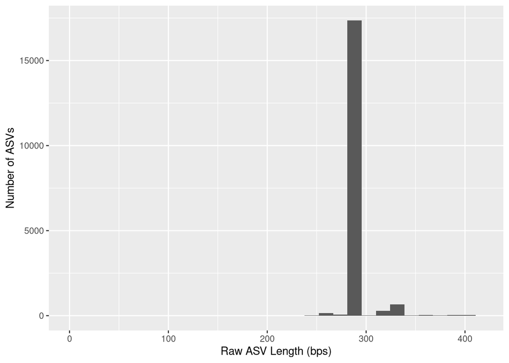

```r
# Inspect the distribution of sequence lengths of all ASVs in data set
# AFTER TRIM
plot_ASVLength_raw <-
  data.frame(Seq_Length = nchar(getSequences(raw_ASV_table))) %>%
  ggplot(aes(x = Seq_Length )) +
  geom_histogram() +
  # include the x-axis scales
  scale_x_continuous(limits = c(0, maxLength_ASV + 5)) +
  labs(y = "Number of ASVs", x = "Raw ASV Length (bps)")

# Show the plot
plot_ASVLength_raw
```

#Trim ASV Lengths

```r
# Subset only ASVs that are 292 bps long
raw_ASV_table_trimmed <-
  raw_ASV_table[,nchar(colnames(raw_ASV_table)) == 292]

# Inspect the distribution of sequence lengths of all ASVs in dataset
table(nchar(getSequences(raw_ASV_table_trimmed)))
```

```
##
##   292
## 15961
```

```r
# What proportion of total ASV sequences are left in the data?
percRetained_Trimmed <- sum((raw_ASV_table_trimmed)/sum(raw_ASV_table)*100)
percRetained_Trimmed # 79.859% are retained... not as good as the 99% in the example
```

```
## [1] 83.61562
```

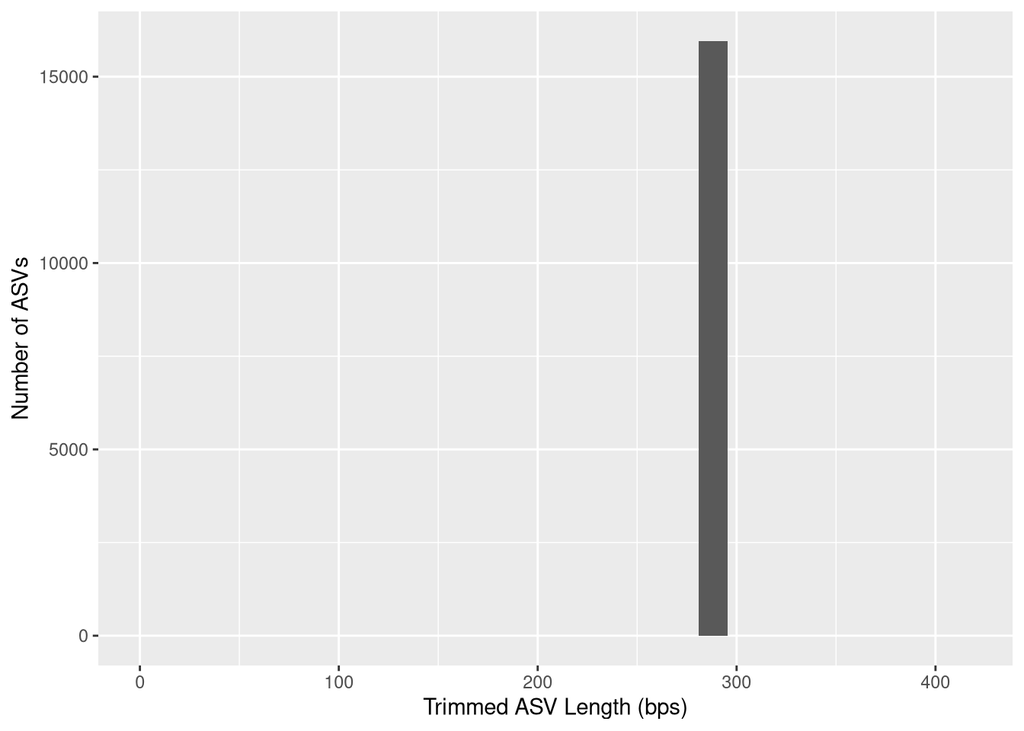

```r
#83.62% Now!
# Inspect the distribution of sequence lengths of all ASVs in dataset
# AFTER TRIM
plot_ASVLength_trimmed <-
  data.frame(Seq_Length = nchar(getSequences(raw_ASV_table_trimmed))) %>%
  ggplot(aes(x = Seq_Length )) +
  geom_histogram() +
  # include the x-axis scales
  scale_x_continuous(limits = c(0, maxLength_ASV + 5)) +
  labs(y = "Number of ASVs", x = "Trimmed ASV Length (bps)")

# Show the plot
plot_ASVLength_trimmed
```

```r
#uhhh my peak is not at 3000 ASVs... visible in dim earlier... uhhh ok?
```

#Remove Chimeras

```r
# Remove the chimeras in the raw ASV table
noChimeras_ASV_table <-
  removeBimeraDenovo(raw_ASV_table_trimmed,
                     method="consensus",
                     multithread = n_threads,
                     verbose=TRUE)
```

```
## Identified 11297 bimeras out of 15961 input sequences.
```

```r
#Identified 590 bimeras out of 1984 input sequences.
#this seems high??
dim(noChimeras_ASV_table) # 250 1394
```

```
## [1]  252 4664
```

```r
# What proportion is left of the sequences?
# Chimera removal compared to trimming
percRetained_chimerasTrimmed <- sum(noChimeras_ASV_table)/sum(raw_ASV_table_trimmed)
# Chimera removal compared to raw
percRetained_chimerasRaw <-sum(noChimeras_ASV_table)/sum(raw_ASV_table)
percRetained_chimerasRaw
```

```
## [1] 0.5690956
```

```r
percRetained_chimerasTrimmed
```

```
## [1] 0.6806092
```

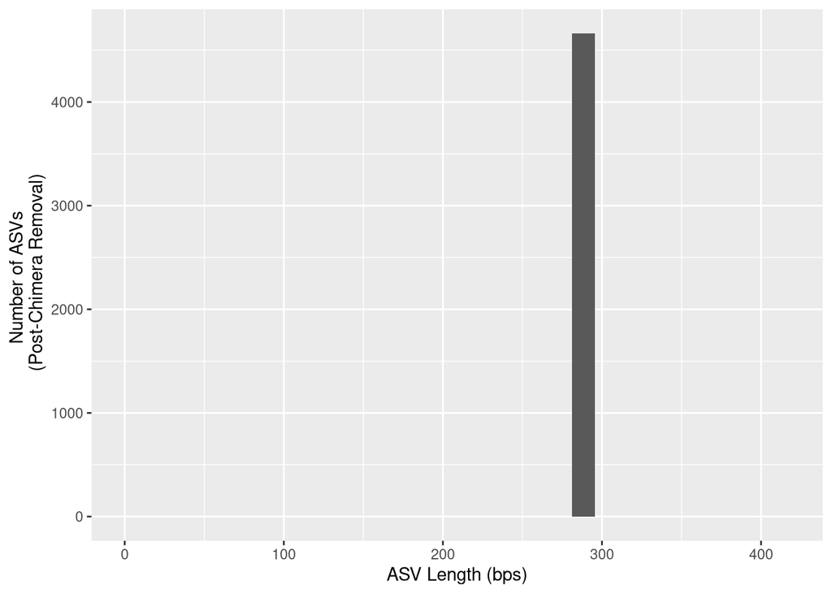

```r
# Plot it
plot_ASVLength_NoChimeras <-
  data.frame(Seq_Length_NoChim = nchar(getSequences(noChimeras_ASV_table))) %>%
  ggplot(aes(x = Seq_Length_NoChim )) +
  geom_histogram()+
  # include the x-axis scales
  scale_x_continuous(limits = c(0, maxLength_ASV + 5)) +
  labs(y = "Number of ASVs \n (Post-Chimera Removal)",
       x = "ASV Length (bps)")

# Show the plot
plot_ASVLength_NoChimeras #ouch
```

#Plot ASV Lengths after Chimera Removal

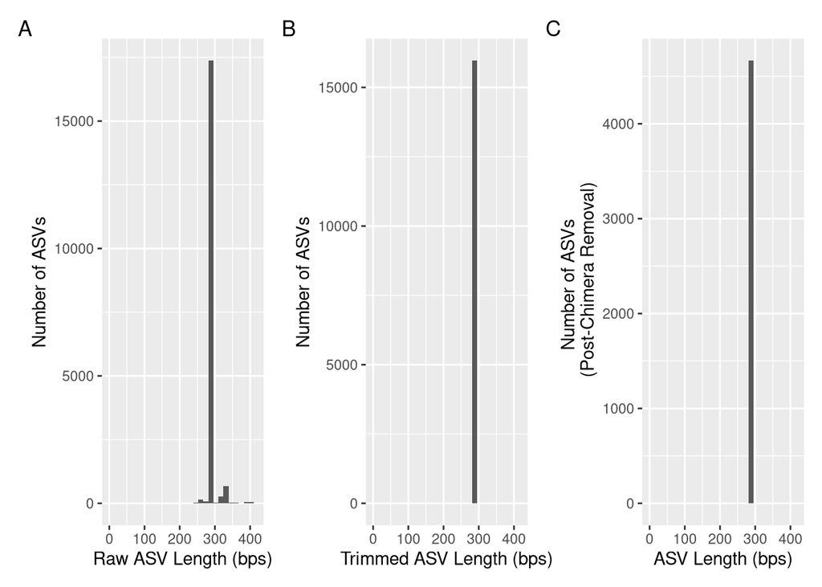

```r
plot_ASVLength_raw + plot_ASVLength_trimmed + plot_ASVLength_NoChimeras +
    plot_annotation(tag_levels = 'A')
```

```r
#so fun! fave plot
```

#Track Read Counts

```r
# A little function to identify number seqs
getN <- function(x) sum(getUniques(x))

# Make the table to track the seqs
track <- cbind(sapply(dada_forward, getN),
               sapply(dada_reverse, getN),
               sapply(merged_ASVs, getN),
               rowSums(noChimeras_ASV_table))

head(track)
```

```
##                                   [,1]  [,2]  [,3]  [,4]
## SRR11917047_R1_filtered.fastq.gz 14438 14292 13869 10730
## SRR11917048_R1_filtered.fastq.gz 33298 33082 31235 19048
## SRR11917049_R1_filtered.fastq.gz 11347 11309 10833  5094
## SRR11917050_R1_filtered.fastq.gz  9952  9828  8934  5968
## SRR11917051_R1_filtered.fastq.gz 17817 17738 15047  9328
## SRR11917052_R1_filtered.fastq.gz  4511  4505  4339   620
```

```r
#ok
# Update column names to be more informative (most are missing at the moment!)
colnames(track) <- c("denoisedF", "denoisedR", "merged", "nochim")
rownames(track) <- row.names(noChimeras_ASV_table)

# Generate a dataframe to track the reads through our DADA2 pipeline
track_counts_df <-
  track %>%
  # make it a dataframe
  as.data.frame() %>%
  rownames_to_column(var = "sample_names")

# Now let's add a column for the number of ASVs
# First, intuition check that the samples match
stopifnot(track_counts_df$sample_names == row.names(noChimeras_ASV_table))

# Now, let's add a new column with the number of ASVs
track_counts_df <-
  track_counts_df %>%
  mutate(num_ASVs = rowSums(noChimeras_ASV_table > 1))

# Visualize it in table format
DT::datatable(track_counts_df)
```

|  | sample_names | denoisedF | denoisedR | merged | nochim | num_ASVs |
| --- | --- | --- | --- | --- | --- | --- |
| 1 | SRR11917047_R1_filtered.fastq.gz | 14438 | 14292 | 13869 | 10730 | 176 |
| 2 | SRR11917048_R1_filtered.fastq.gz | 33298 | 33082 | 31235 | 19048 | 228 |
| 3 | SRR11917049_R1_filtered.fastq.gz | 11347 | 11309 | 10833 | 5094 | 91 |
| 4 | SRR11917050_R1_filtered.fastq.gz | 9952 | 9828 | 8934 | 5968 | 185 |
| 5 | SRR11917051_R1_filtered.fastq.gz | 17817 | 17738 | 15047 | 9328 | 158 |
| 6 | SRR11917052_R1_filtered.fastq.gz | 4511 | 4505 | 4339 | 620 | 7 |
| 7 | SRR11917053_R1_filtered.fastq.gz | 7610 | 7596 | 7183 | 4522 | 162 |
| 8 | SRR11917054_R1_filtered.fastq.gz | 5807 | 5805 | 5520 | 4029 | 120 |
| 9 | SRR11917055_R1_filtered.fastq.gz | 2583 | 2570 | 2436 | 1670 | 47 |
| 10 | SRR11917056_R1_filtered.fastq.gz | 9257 | 9304 | 8720 | 5391 | 56 |

[output cut: 242 more lines]

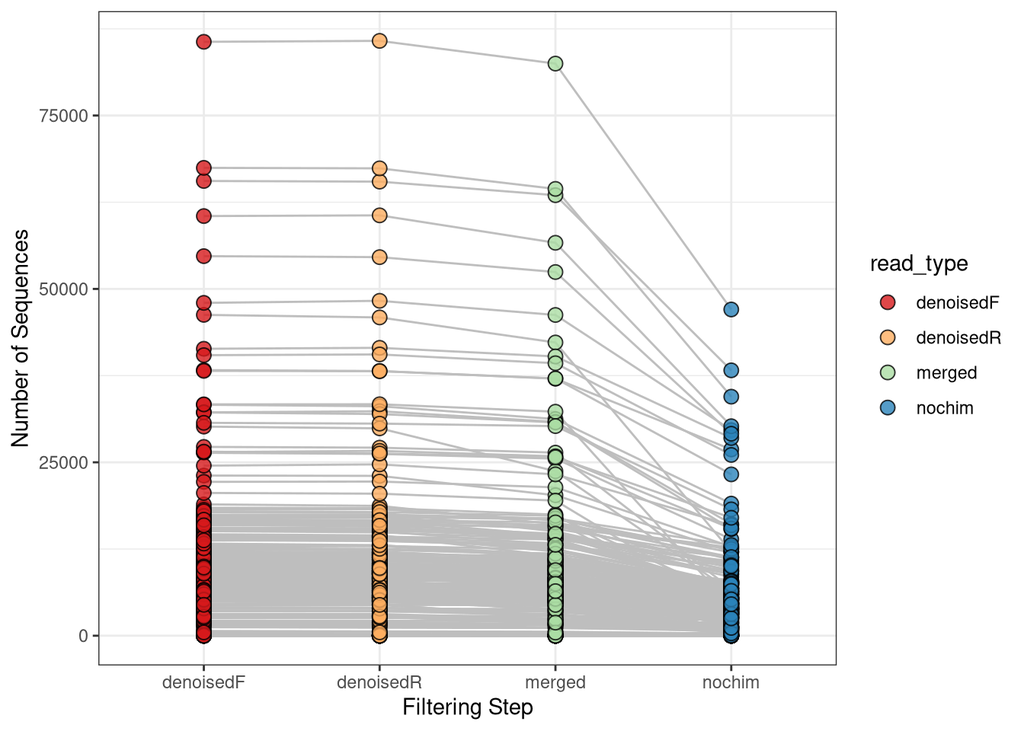

```r
#cool... plot it?
track_counts_df %>%
  pivot_longer(denoisedF:nochim, names_to = "read_type", values_to = "num_reads") %>%
  mutate(read_type = fct_relevel(read_type, "denoisedF", "denoisedR", "merged", "nochim")) %>%
  ggplot(aes(x = read_type, y = num_reads, fill = read_type)) +
  geom_line(aes(group = sample_names), color = "grey") +
  geom_point(shape = 21, size = 3, alpha = 0.8) +
  scale_fill_brewer(palette = "Spectral") +
  labs(x = "Filtering Step", y = "Number of Sequences") +
  theme_bw()
```

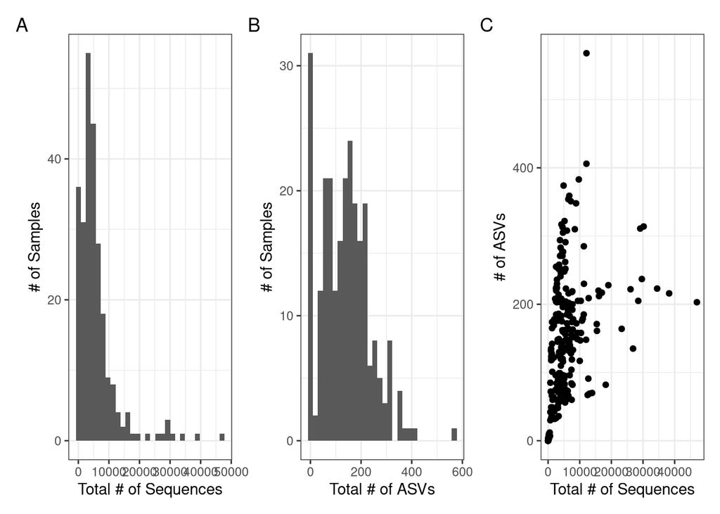

```r
#well... uhh

#plot it
plot_ReadDepth <-
  track_counts_df %>%
  ggplot(aes(x = nochim)) +
  geom_histogram() +
  labs(x = "Total # of Sequences", y = "# of Samples") +
  theme_bw()

# What is the ASV richness per sample?
plot_ASVRichness <-
  track_counts_df %>%
  ggplot(aes(x = num_ASVs)) +
  geom_histogram() +
  labs(x = "Total # of ASVs", y = "# of Samples") +
  theme_bw()

# Now, let's look at the relationship of ASVs and Sequencing depth
plot_ReadDepth_ASVRichness <-
  track_counts_df %>%
  ggplot(aes(x = nochim, y = num_ASVs)) +
  geom_point() +
  labs(x = "Total # of Sequences", y = "# of ASVs") +
  theme_bw()

# Show the plots together
plot_ReadDepth + plot_ASVRichness + plot_ReadDepth_ASVRichness +
    plot_annotation(tag_levels = 'A')
```

```r
#well that just doesn't look good.
```

#Assign Taxonomy Here, we will use the silva database version 138.2, which has been properly formatted for DADA2. The files came from this DADA2-formatted reference databases website, which hosts several other reference taxomoy files for several popular taxonomic databases.

```r
# Assign up to genus level
taxa_train <-
  assignTaxonomy(noChimeras_ASV_table,
                 refFasta = "/workdir/in_class_data/taxonomy/silva_nr99_v138.2_toGenus_trainset.fa.gz",
                 multithread = n_threads)

# Add the genus/species information
taxa_addSpecies <-
  addSpecies(taxa_train,
              refFasta = "/workdir/in_class_data/taxonomy/silva_v138.2_assignSpecies.fa.gz")

# Inspect the taxonomy
glimpse(taxa_addSpecies) # Note that the rownames are the ASV sequences!\# Let's removing the ASV sequence rownames for display only
```

```
##  chr [1:4664, 1:7] "Bacteria" "Bacteria" "Bacteria" "Bacteria" "Bacteria" ...
##  - attr(*, "dimnames")=List of 2
##   ..$ : chr [1:4664] "GTGTCAGCAGCCGCGGTAATACAGAGGGTGCAAGCGTTAATCGGAATTACTGGGCGTAAAGCGCGCGTAGGTGGTTTGTTAAGTTGAATGTGAAATCCCCGGGCTCAACCT"| __truncated__ "GTGTCAGCAGCCGCGGTAATACAGAGGATGCAAGCGTTATCCGGAATGATTGGGCGTAAAGCGTCTGTAGGTGGCTTTTTAAGTCCGCCGTCAAATCCCAGGGCTCATCCC"| __truncated__ "GTGCCAGCAGCCGCGGT…
##   ..$ : chr [1:7] "Kingdom" "Phylum" "Class" "Order" ...
```

```r
taxa_print <- taxa_addSpecies
rownames(taxa_print) <- NULL
head(taxa_print)
```

```
##      Kingdom    Phylum            Class                 Order
## [1,] "Bacteria" "Pseudomonadota"  "Gammaproteobacteria" "Pseudomonadales"
## [2,] "Bacteria" "Cyanobacteriota" "Cyanobacteriia"      "Chloroplast"
## [3,] "Bacteria" "Pseudomonadota"  "Gammaproteobacteria" "Pseudomonadales"
## [4,] "Bacteria" "Cyanobacteriota" "Cyanobacteriia"      "Chloroplast"
## [5,] "Bacteria" "Pseudomonadota"  "Gammaproteobacteria" "Pseudomonadales"
## [6,] "Bacteria" "Pseudomonadota"  "Gammaproteobacteria" "Pseudomonadales"
##      Family             Genus         Species
## [1,] "Pseudomonadaceae" "Pseudomonas" NA
## [2,] NA                 NA            NA
## [3,] "Pseudomonadaceae" "Pseudomonas" NA
## [4,] NA                 NA            NA
## [5,] "Pseudomonadaceae" "Pseudomonas" NA
## [6,] "Pseudomonadaceae" "Pseudomonas" NA
```

#EXPORTING ##1. ASV Tables Let’s check that the ASVs are in the rows and the sample names are in the columns. If not, we can use the transpose function t() in R.

```r
# What's the current format of the ASV table?
head(rownames(noChimeras_ASV_table)) # Samples!
```

```
## [1] "SRR11917047_R1_filtered.fastq.gz" "SRR11917048_R1_filtered.fastq.gz"
## [3] "SRR11917049_R1_filtered.fastq.gz" "SRR11917050_R1_filtered.fastq.gz"
## [5] "SRR11917051_R1_filtered.fastq.gz" "SRR11917052_R1_filtered.fastq.gz"
```

```r
head(colnames(noChimeras_ASV_table)) # ASV Sequences
```

```
## [1] "GTGTCAGCAGCCGCGGTAATACAGAGGGTGCAAGCGTTAATCGGAATTACTGGGCGTAAA…"
## [2] "GTGTCAGCAGCCGCGGTAATACAGAGGATGCAAGCGTTATCCGGAATGATTGGGCGTAAA…"
## [3] "GTGCCAGCAGCCGCGGTAATACAGAGGGTGCAAGCGTTAATCGGAATTACTGGGCGTAAA…"
## [4] "GTGCCAGCAGCCGCGGTAATACAGAGGATGCAAGCGTTATCCGGAATGATTGGGCGTAAA…"
## [5] "GTGTCAGCCGCCGCGGTAATACAGAGGGTGCAAGCGTTAATCGGAATTACTGGGCGTAAA…"
## [6] "GTGTCAGCAGCCGCGGTAATACAGAGGGTGCAAGCGTTAATCGGAATTACTGGGCGTAAA…"
```

```r
# Therefore, we need to transpose the matrix
final_ASV_table_withSeqs <- t(noChimeras_ASV_table)

# Intuition check
head(rownames(final_ASV_table_withSeqs)) # ASV Sequences
```

```
## [1] "GTGTCAGCAGCCGCGGTAATACAGAGGGTGCAAGCGTTAATCGGAATTACTGGGCGTAAA…"
## [2] "GTGTCAGCAGCCGCGGTAATACAGAGGATGCAAGCGTTATCCGGAATGATTGGGCGTAAA…"
## [3] "GTGCCAGCAGCCGCGGTAATACAGAGGGTGCAAGCGTTAATCGGAATTACTGGGCGTAAA…"
## [4] "GTGCCAGCAGCCGCGGTAATACAGAGGATGCAAGCGTTATCCGGAATGATTGGGCGTAAA…"
## [5] "GTGTCAGCCGCCGCGGTAATACAGAGGGTGCAAGCGTTAATCGGAATTACTGGGCGTAAA…"
## [6] "GTGTCAGCAGCCGCGGTAATACAGAGGGTGCAAGCGTTAATCGGAATTACTGGGCGTAAA…"
```

```r
head(colnames(final_ASV_table_withSeqs)) # Sample names
```

```
## [1] "SRR11917047_R1_filtered.fastq.gz" "SRR11917048_R1_filtered.fastq.gz"
## [3] "SRR11917049_R1_filtered.fastq.gz" "SRR11917050_R1_filtered.fastq.gz"
## [5] "SRR11917051_R1_filtered.fastq.gz" "SRR11917052_R1_filtered.fastq.gz"
```

```r
# Now, add a break in the script break if this isn't true!
# Let's make sure the sample names match the file names in the matrix.
stopifnot(sapply(strsplit(colnames(final_ASV_table_withSeqs), "_"), `[`,1) == sample_names)

# Now, we've done some checks to prove to ourselves there will be no silent errors,
# Let's rename!
colnames(final_ASV_table_withSeqs) <- sample_names
head(colnames(final_ASV_table_withSeqs))
```

```
## [1] "SRR11917047" "SRR11917048" "SRR11917049" "SRR11917050" "SRR11917051"
## [6] "SRR11917052"
```

### Names in ASV tables

#### Fix Sample Names

Notice above that the sample names are actually file names. Let’s fix this!

> WARNING! This is an easy place where a silent error can step in where we could misname our samples, leading to catastrophe down the road. So, we need to be very careful and complete our checks and balances so we ensure the samples are not mixed up in the renaming process.

Reminder of output goals: 1. ASV Count Table: asv_table (with and without sequence names) 2. ASV fasta file: asvs_fasta for building a phylogenetic tree at a later step. 3. Taxonomy Table tax_table 4. Sample Information: sample_data track the reads lots throughout DADA2 workflow.

```r
# Remember at the top of the file we created a vector of sample names
head(sample_names)
```

```
## [1] "SRR11917047" "SRR11917048" "SRR11917049" "SRR11917050" "SRR11917051"
## [6] "SRR11917052"
```

```r
# Let's check with the actual column names
head(colnames(final_ASV_table_withSeqs)) # Sample names
```

```
## [1] "SRR11917047" "SRR11917048" "SRR11917049" "SRR11917050" "SRR11917051"
## [6] "SRR11917052"
```

```r
# And then apply our sample name script to check, too
head(sapply(strsplit(colnames(final_ASV_table_withSeqs), "_"), `[`,1)) # Looks good!
```

```
## [1] "SRR11917047" "SRR11917048" "SRR11917049" "SRR11917050" "SRR11917051"
## [6] "SRR11917052"
```

```r
# Now, add a break in the script break if this isn't true!
# Let's make sure the sample names match the file names in the matrix.
stopifnot(sapply(strsplit(colnames(final_ASV_table_withSeqs), "_"), `[`,1) == sample_names)

# Now, we've done some checks to prove to ourselves there will be no silent errors,
# Let's rename!
colnames(final_ASV_table_withSeqs) <- sample_names
head(colnames(final_ASV_table_withSeqs))
```

```
## [1] "SRR11917047" "SRR11917048" "SRR11917049" "SRR11917050" "SRR11917051"
## [6] "SRR11917052"
```

#### Rename ASVs

Then, we can also fix the names of our ASVs for our second ASV table where we will replace the ASV sequence names with ASV_1, ASV_2

```r
# Give headers more manageable names
# First pull the ASV sequences from the rownames
ASV_seqs <- rownames(final_ASV_table_withSeqs)
ASV_seqs[1:5]
```

```
## [1] "GTGTCAGCAGCCGCGGTAATACAGAGGGTGCAAGCGTTAATCGGAATTACTGGGCGTAAA…"
## [2] "GTGTCAGCAGCCGCGGTAATACAGAGGATGCAAGCGTTATCCGGAATGATTGGGCGTAAA…"
## [3] "GTGCCAGCAGCCGCGGTAATACAGAGGGTGCAAGCGTTAATCGGAATTACTGGGCGTAAA…"
## [4] "GTGCCAGCAGCCGCGGTAATACAGAGGATGCAAGCGTTATCCGGAATGATTGGGCGTAAA…"
## [5] "GTGTCAGCCGCCGCGGTAATACAGAGGGTGCAAGCGTTAATCGGAATTACTGGGCGTAAA…"
```

```r
# How many ASVs?
num_ASVs <- dim(final_ASV_table_withSeqs)[1] # select the number of rows
num_ASVs
```

```
## [1] 4664
```

```r
# Make an empty vector the length of the number of ASVs,
# which is where we will place the new operational ASV names
ASV_headers <- vector(num_ASVs, mode = "character")

# Let's mae sure we have an empty vector!
ASV_headers[1:5]
```

```
## [1] "" "" "" "" ""
```

```r
length(ASV_headers) # looks good!
```

```
## [1] 4664
```

```r
# Now, let's create a vector with ASV numbers
# loop through vector and fill it in with ASV names
for (i in 1:num_ASVs) {
  # Add leading zero to ASV name so they print in correct order.
  ASV_number <- sprintf("%04d", i)
  # Now, rename each spot in the ASV header vector as we loop through the for loop
  ASV_headers[i] <- paste(">ASV", ASV_number, sep = "_")
}
ASV_headers[1:5]
```

```
## [1] ">ASV_0001" ">ASV_0002" ">ASV_0003" ">ASV_0004" ">ASV_0005"
```

```r
# Create a new ASV table, which will have the ASV numbers as names
# View(noChimeras_ASV_table) # To view the table
final_ASV_table <- final_ASV_table_withSeqs
glimpse(final_ASV_table)
```

```
##  int [1:4664, 1:252] 363 91 345 71 269 162 185 84 0 62 ...
##  - attr(*, "dimnames")=List of 2
##   ..$ : chr [1:4664] "GTGTCAGCAGCCGCGGTAATACAGAGGGTGCAAGCGTTAATCGGAATTACTGGGCGTAAAGCGCGCGTAGGTGGTTTGTTAAGTTGAATGTGAAATCCCCGGGCTCAACCT"| __truncated__ "GTGTCAGCAGCCGCGGTAATACAGAGGATGCAAGCGTTATCCGGAATGATTGGGCGTAAAGCGTCTGTAGGTGGCTTTTTAAGTCCGCCGTCAAATCCCAGGGCTCATCCC"| __truncated__ "GTGCCAGCAGCCGCGGT…
##   ..$ : chr [1:252] "SRR11917047" "SRR11917048" "SRR11917049" "SRR11917050" ...
```

```r
## Replace the ASV seqs with the ASV numbers
row.names(final_ASV_table) <- sub(">", "", ASV_headers)
final_ASV_table[1:5, 1:5]
```

```
##          SRR11917047 SRR11917048 SRR11917049 SRR11917050 SRR11917051
## ASV_0001         363          68           0          60         114
## ASV_0002          91         878         243         326           0
## ASV_0003         345          55           0           0           0
## ASV_0004          71         635         268         292           0
## ASV_0005         269          47           0           0           0
```

```r
#View(final_ASV_table) # To view the table
```

### Write the ASV Tables!

```r
# 1. Write count table with ASV sequence names
write.table(final_ASV_table_withSeqs,
            file = "/local/workdir/erw98/Brassica_Growth_2026/data/02_AssigningASVs/ASV_table_withSeqNames.tsv",
            sep = "\t", quote = FALSE, col.names = NA)

# 2. Write count table with ASV numbered names (e.g. ASV_1, ASV_2, etc)
write.table(final_ASV_table,
            file = "/local/workdir/erw98/Brassica_Growth_2026/data/02_AssigningASVs/ASV_table.tsv",
            sep = "\t", quote = FALSE, col.names = NA)
```

## 2. ASV Fasta File

Now, let’s create a fasta file that has our ASV numbers with each of their corresponding ASV sequences. This file needs to be created because we will use it later to build a phylogenetic tree.

**Why do we need a phylogenetic tree?** Many widely used microbial ecology metrics rely on phylogenetic relationships to quantify community similarity. For example, there are phylogenetic alpha-diversity metrics like the [phylogenetic Hill Numbers](https://www.annualreviews.org/content/journals/10.1146/annurev-ecolsys-120213-091540) and also beta-diversity measures that incorporate the branch lenghts of phylogenetic trees as it relates to community dissimimlarity, [like the abundance-unweighted and abundance-weighted UniFrac dissimilarity metrics](https://journals.asm.org/doi/full/10.1128/aem.71.12.8228-8235.2005). These metrics consider species presence and their evolutionary distances, conveying relationships of communities through an ecological *and* evolutionary framework.

### Write the ASV Fasta File

```r
# Let's take our asv_headers
head(ASV_headers, n = 2)
```

```
## [1] ">ASV_0001" ">ASV_0002"
```

```r
# And combine it with their sequences
head(ASV_seqs, n = 2)
```

```
## [1] "GTGTCAGCAGCCGCGGTAATACAGAGGGTGCAAGCGTTAATCGGAATTACTGGGCGTAAA…"
## [2] "GTGTCAGCAGCCGCGGTAATACAGAGGATGCAAGCGTTATCCGGAATGATTGGGCGTAAA…"
```

```r
# Combine in a fasta format with the cbind() function
ASV_fasta <- c(rbind(ASV_headers, ASV_seqs))
head(ASV_fasta, n = 4)
```

```
## [1] ">ASV_0001"
## [2] "GTGTCAGCAGCCGCGGTAATACAGAGGGTGCAAGCGTTAATCGGAATTACTGGGCGTAAA…"
## [3] ">ASV_0002"
## [4] "GTGTCAGCAGCCGCGGTAATACAGAGGATGCAAGCGTTATCCGGAATGATTGGGCGTAAA…"
```

```r
# Then, let's write it to a fasta file!
# This will be our reference later on for which seq matches which ASV
write(ASV_fasta, "/local/workdir/erw98/Brassica_Growth_2026/data/02_AssigningASVs/ASVs.fasta")
```

## 3. Taxonomy Table

Before we actually write the taxonomy table, let’s put the ASV sequences as another column in our taxonomy table and then replace the rownames to be our numbered ASV names.

### Reformat Taxonomy

1. Move ASV sequences to column
2. Replace ASV rownames with ASV numbered names

> WARNING! This is another easy place where a silent error can step in!! Here, we could accidentally misname our ASVs. So, we need to be very careful and perform intuition checks to ensure that the ASV names are not mixed up in the renaming process.

```r
# Inspect the taxonomy table
dim(taxa_addSpecies) # ASVs are in rows and Kingdom, Phylum, etc in Columns
```

```
## [1] 4664    7
```

```r
colnames(taxa_addSpecies) # Column names are Linnean Taxonomy
```

```
## [1] "Kingdom" "Phylum"  "Class"   "Order"   "Family"  "Genus"   "Species"
```

```r
head(rownames(taxa_addSpecies), n = 2) # ASV names are rownames
```

```
## [1] "GTGTCAGCAGCCGCGGTAATACAGAGGGTGCAAGCGTTAATCGGAATTACTGGGCGTAAA…"
## [2] "GTGTCAGCAGCCGCGGTAATACAGAGGATGCAAGCGTTATCCGGAATGATTGGGCGTAAA…"
```

```r
class(taxa_addSpecies) # Character matrix
```

```
## [1] "matrix" "array"
```

```r
##### Prepare tax table
# 1. Add the ASV sequences from the rownames to a column
new_tax_table <-
  taxa_addSpecies%>%
  as.data.frame() %>%
  rownames_to_column(var = "ASVseqs")

# Intuition check
glimpse(new_tax_table)
```

```
## Rows: 4,664
## Columns: 8
## $ ASVseqs <chr> "GTGTCAGCAGCCGCGGTAATACAGAGGGTGCAAGCGTTAATCGGAATTACTGGGCGTAAAG…
## $ Kingdom <chr> "Bacteria", "Bacteria", "Bacteria", "Bacteria", "Bacteria", "B…
## $ Phylum  <chr> "Pseudomonadota", "Cyanobacteriota", "Pseudomonadota", "Cyanob…
## $ Class   <chr> "Gammaproteobacteria", "Cyanobacteriia", "Gammaproteobacteria"…
## $ Order   <chr> "Pseudomonadales", "Chloroplast", "Pseudomonadales", "Chloropl…
## $ Family  <chr> "Pseudomonadaceae", NA, "Pseudomonadaceae", NA, "Pseudomonadac…
## $ Genus   <chr> "Pseudomonas", NA, "Pseudomonas", NA, "Pseudomonas", "Pseudomo…
## $ Species <chr> NA, NA, NA, NA, NA, NA, NA, NA, NA, NA, NA, NA, NA, NA, NA, NA…
```

```r
# IMPORTANT! Let's do our intuition check
# This is where we ensure we don't mix up the ASV names!
stopifnot(new_tax_table$ASVseqs == rownames(final_ASV_table_withSeqs))

# Now let's add the ASV names
rownames(new_tax_table) <- rownames(final_ASV_table)
head(new_tax_table)
```

```
##                                                                                                                                                                                                                                                                                                       ASV…
## ASV_0001 GTGTCAGCAGCCGCGGTAATACAGAGGGTGCAAGCGTTAATCGGAATTACTGGGCGTAAA…
## ASV_0002 GTGTCAGCAGCCGCGGTAATACAGAGGATGCAAGCGTTATCCGGAATGATTGGGCGTAAA…
## ASV_0003 GTGCCAGCAGCCGCGGTAATACAGAGGGTGCAAGCGTTAATCGGAATTACTGGGCGTAAA…
## ASV_0004 GTGCCAGCAGCCGCGGTAATACAGAGGATGCAAGCGTTATCCGGAATGATTGGGCGTAAA…
## ASV_0005 GTGTCAGCCGCCGCGGTAATACAGAGGGTGCAAGCGTTAATCGGAATTACTGGGCGTAAA…
## ASV_0006 GTGTCAGCAGCCGCGGTAATACAGAGGGTGCAAGCGTTAATCGGAATTACTGGGCGTAAA…
##           Kingdom          Phylum               Class           Order
## ASV_0001 Bacteria  Pseudomonadota Gammaproteobacteria Pseudomonadales
## ASV_0002 Bacteria Cyanobacteriota      Cyanobacteriia     Chloroplast
## ASV_0003 Bacteria  Pseudomonadota Gammaproteobacteria Pseudomonadales
## ASV_0004 Bacteria Cyanobacteriota      Cyanobacteriia     Chloroplast
## ASV_0005 Bacteria  Pseudomonadota Gammaproteobacteria Pseudomonadales
## ASV_0006 Bacteria  Pseudomonadota Gammaproteobacteria Pseudomonadales
##                    Family       Genus Species
## ASV_0001 Pseudomonadaceae Pseudomonas    <NA>
## ASV_0002             <NA>        <NA>    <NA>
## ASV_0003 Pseudomonadaceae Pseudomonas    <NA>
## ASV_0004             <NA>        <NA>    <NA>
## ASV_0005 Pseudomonadaceae Pseudomonas    <NA>
## ASV_0006 Pseudomonadaceae Pseudomonas    <NA>
```

```r
### Final prep of tax table. Add new column with ASV names
ASV_tax_table <-
  new_tax_table %>%
  # add rownames from count table for phyloseq handoff
  mutate(ASV = rownames(final_ASV_table)) %>%
  # Reorder the columns
  dplyr::select(Kingdom, Phylum, Class, Order, Family, Genus, Species, ASV, ASVseqs)

# Assign the rownames, which is required by phyloseq
rownames(ASV_tax_table) <- ASV_tax_table$ASV

# Take a quick look
glimpse(ASV_tax_table)
```

```
## Rows: 4,664
## Columns: 9
## $ Kingdom <chr> "Bacteria", "Bacteria", "Bacteria", "Bacteria", "Bacteria", "B…
## $ Phylum  <chr> "Pseudomonadota", "Cyanobacteriota", "Pseudomonadota", "Cyanob…
## $ Class   <chr> "Gammaproteobacteria", "Cyanobacteriia", "Gammaproteobacteria"…
## $ Order   <chr> "Pseudomonadales", "Chloroplast", "Pseudomonadales", "Chloropl…
## $ Family  <chr> "Pseudomonadaceae", NA, "Pseudomonadaceae", NA, "Pseudomonadac…
## $ Genus   <chr> "Pseudomonas", NA, "Pseudomonas", NA, "Pseudomonas", "Pseudomo…
## $ Species <chr> NA, NA, NA, NA, NA, NA, NA, NA, NA, NA, NA, NA, NA, NA, NA, NA…
## $ ASV     <chr> "ASV_0001", "ASV_0002", "ASV_0003", "ASV_0004", "ASV_0005", "A…
## $ ASVseqs <chr> "GTGTCAGCAGCCGCGGTAATACAGAGGGTGCAAGCGTTAATCGGAATTACTGGGCGTAAAG…
```

```r
# Intution check
stopifnot(ASV_tax_table$ASV == rownames(ASV_tax_table),
          rownames(ASV_tax_table) == rownames(ASV_tax_table))
```

### Write the Taxonomy Table

##Now, let’s write out the taxonomy table

```r
# Write the table
write.table(ASV_tax_table,
            file = "/local/workdir/erw98/Brassica_Growth_2026/data/02_AssigningASVs/ASV_taxonomy.tsv",
            sep = "\t", quote = FALSE, col.names = NA)
```

## 4. DADA2 Sample Data

Let’s save the `track_counts_df`, which can be useful for downstream analyses.

```r
# And save the track_counts_df a R object, which we will merge with metadata information in the next step of the analysis in analysis/02_Taxonomic_Assignment.
save(track_counts_df, file = "/local/workdir/erw98/Brassica_Growth_2026/data/02_AssigningASVs/track_read_counts.RData")
```

# Phyloseq S4 Object Creation

To start this section of this lesson, please make sure that you have phyloseq installed!

### 5. Metadata

```r
# 1. Import the CSV file
Sra_df <- read.csv("/local/workdir/erw98/Brassica_Growth_2026/data/SraRunTable.csv")
#View(final_ASV_table)
rownames(Sra_df) <- Sra_df$Run
metadata_physeq <- sample_data(Sra_df)
sample_names(metadata_physeq)
```

```
##   [1] "SRR11917047" "SRR11917048" "SRR11917049" "SRR11917050" "SRR11917051"
##   [6] "SRR11917052" "SRR11917053" "SRR11917054" "SRR11917055" "SRR11917056"
##  [11] "SRR11917057" "SRR11917058" "SRR11917059" "SRR11917060" "SRR11917061"
##  [16] "SRR11917062" "SRR11917063" "SRR11917064" "SRR11917065" "SRR11917066"
##  [21] "SRR11917067" "SRR11917068" "SRR11917069" "SRR11917070" "SRR11917071"
##  [26] "SRR11917072" "SRR11917073" "SRR11917074" "SRR11917075" "SRR11917076"
##  [31] "SRR11917077" "SRR11917078" "SRR11917079" "SRR11917080" "SRR11917081"
##  [36] "SRR11917082" "SRR11917083" "SRR11917084" "SRR11917085" "SRR11917086"
##  [41] "SRR11917087" "SRR11917088" "SRR11917089" "SRR11917090" "SRR11917091"
##  [46] "SRR11917092" "SRR11917093" "SRR11917094" "SRR11917095" "SRR11917096"
##  [51] "SRR11917097" "SRR11917098" "SRR11917099" "SRR11917100" "SRR11917101"
##  [56] "SRR11917102" "SRR11917103" "SRR11917104" "SRR11917105" "SRR11917106"
##  [61] "SRR11917107" "SRR11917108" "SRR11917109" "SRR11917110" "SRR11917111"
##  [66] "SRR11917112" "SRR11917113" "SRR11917114" "SRR11917115" "SRR11917116"
##  [71] "SRR11917117" "SRR11917118" "SRR11917119" "SRR11917120" "SRR11917121"
```

[output cut: 37 more lines]

```r
colnames(final_ASV_table)
```

```
##   [1] "SRR11917047" "SRR11917048" "SRR11917049" "SRR11917050" "SRR11917051"
##   [6] "SRR11917052" "SRR11917053" "SRR11917054" "SRR11917055" "SRR11917056"
##  [11] "SRR11917057" "SRR11917058" "SRR11917059" "SRR11917060" "SRR11917061"
##  [16] "SRR11917062" "SRR11917063" "SRR11917064" "SRR11917065" "SRR11917066"
##  [21] "SRR11917067" "SRR11917068" "SRR11917069" "SRR11917070" "SRR11917071"
##  [26] "SRR11917072" "SRR11917073" "SRR11917074" "SRR11917075" "SRR11917076"
##  [31] "SRR11917077" "SRR11917078" "SRR11917079" "SRR11917080" "SRR11917081"
##  [36] "SRR11917082" "SRR11917083" "SRR11917084" "SRR11917085" "SRR11917086"
##  [41] "SRR11917087" "SRR11917088" "SRR11917089" "SRR11917090" "SRR11917091"
##  [46] "SRR11917092" "SRR11917093" "SRR11917094" "SRR11917095" "SRR11917096"
##  [51] "SRR11917097" "SRR11917098" "SRR11917099" "SRR11917100" "SRR11917101"
##  [56] "SRR11917103" "SRR11917104" "SRR11917106" "SRR11917107" "SRR11917108"
##  [61] "SRR11917109" "SRR11917110" "SRR11917111" "SRR11917112" "SRR11917113"
##  [66] "SRR11917114" "SRR11917115" "SRR11917116" "SRR11917117" "SRR11917118"
##  [71] "SRR11917119" "SRR11917120" "SRR11917121" "SRR11917122" "SRR11917123"
```

[output cut: 36 more lines]

```r
#stopifnot(all(sample_names(metadata_physeq) == colnames(final_ASV_table)))
#troubleshooting this stop:
length(sample_names(metadata_physeq))
```

```
## [1] 256
```

```r
length(colnames(final_ASV_table))
```

```
## [1] 252
```

```r
#see a difference in # of samples
head(sample_names(metadata_physeq))
```

```
## [1] "SRR11917047" "SRR11917048" "SRR11917049" "SRR11917050" "SRR11917051"
## [6] "SRR11917052"
```

```r
head(colnames(final_ASV_table))
```

```
## [1] "SRR11917047" "SRR11917048" "SRR11917049" "SRR11917050" "SRR11917051"
## [6] "SRR11917052"
```

```r
#find the overlap
intersect_samples <- intersect(
  sample_names(metadata_physeq),
  colnames(final_ASV_table)
)

length(intersect_samples)
```

```
## [1] 252
```

```r
#252 is the number I want. Which ones are overlap?
setdiff(colnames(final_ASV_table), sample_names(metadata_physeq))  # in ASV only
```

```
## character(0)
```

```r
setdiff(sample_names(metadata_physeq), colnames(final_ASV_table))  # in metadata only
```

```
## [1] "SRR11917102" "SRR11917105" "SRR11917230" "SRR11917268"
```

```r
#intersect them
# Subset ASV table
final_ASV_table <- final_ASV_table[, intersect_samples]

# Subset metadata
metadata_physeq <- metadata_physeq[intersect_samples, ]

#check again
stopifnot(all(sample_names(metadata_physeq) == colnames(final_ASV_table)))
length(filtered_forward_reads)
```

```
## [1] 252
```

```r
length(filtered_reverse_reads)
```

```
## [1] 252
```

```r
all(basename(filtered_forward_reads) %in% basename(filtered_reverse_reads))
```

```
## [1] FALSE
```

```r
get_sample_id <- function(x) {
  sub("_R[12]_filtered.fastq.gz", "", basename(x))
}

forward_ids <- get_sample_id(filtered_forward_reads)
reverse_ids <- get_sample_id(filtered_reverse_reads)
all(forward_ids %in% reverse_ids)
```

```
## [1] TRUE
```

```r
all(reverse_ids %in% forward_ids)
```

```
## [1] TRUE
```

```r
# Reorder reverse reads to match forward reads
filtered_reverse_reads <- filtered_reverse_reads[
  match(forward_ids, reverse_ids)
]

# Final safety check
stopifnot(all(get_sample_id(filtered_forward_reads) ==
              get_sample_id(filtered_reverse_reads)))
head(forward_ids)
```

```
## [1] "SRR11917047" "SRR11917048" "SRR11917049" "SRR11917050" "SRR11917051"
## [6] "SRR11917052"
```

```r
head(reverse_ids)
```

```
## [1] "SRR11917047" "SRR11917048" "SRR11917049" "SRR11917050" "SRR11917051"
## [6] "SRR11917052"
```

```r
#rebuild phyloseq object
raw_physeq <- phyloseq(
  otu_table(final_ASV_table, taxa_are_rows = TRUE),
  tax_table(as.matrix(ASV_tax_table)),
  metadata_physeq
)
# 2. Save the object to an .RData file
save(Sra_df, file = "/local/workdir/erw98/Brassica_Growth_2026/metadata.RData")

# read the SRA run table into R. This is my equivalent of the metadata, right?
#load("/local/workdir/erw98/Brassica_Growth_2026/metadata.RData")
#Sra_df
# The command above will load in a new object called:
#rename it:
#metadata_physeq <- Sra_df
#View(metadata_physeq)
# Check it out
sample_names(metadata_physeq)
```

```
##   [1] "SRR11917047" "SRR11917048" "SRR11917049" "SRR11917050" "SRR11917051"
##   [6] "SRR11917052" "SRR11917053" "SRR11917054" "SRR11917055" "SRR11917056"
##  [11] "SRR11917057" "SRR11917058" "SRR11917059" "SRR11917060" "SRR11917061"
##  [16] "SRR11917062" "SRR11917063" "SRR11917064" "SRR11917065" "SRR11917066"
##  [21] "SRR11917067" "SRR11917068" "SRR11917069" "SRR11917070" "SRR11917071"
##  [26] "SRR11917072" "SRR11917073" "SRR11917074" "SRR11917075" "SRR11917076"
##  [31] "SRR11917077" "SRR11917078" "SRR11917079" "SRR11917080" "SRR11917081"
##  [36] "SRR11917082" "SRR11917083" "SRR11917084" "SRR11917085" "SRR11917086"
##  [41] "SRR11917087" "SRR11917088" "SRR11917089" "SRR11917090" "SRR11917091"
##  [46] "SRR11917092" "SRR11917093" "SRR11917094" "SRR11917095" "SRR11917096"
##  [51] "SRR11917097" "SRR11917098" "SRR11917099" "SRR11917100" "SRR11917101"
##  [56] "SRR11917103" "SRR11917104" "SRR11917106" "SRR11917107" "SRR11917108"
##  [61] "SRR11917109" "SRR11917110" "SRR11917111" "SRR11917112" "SRR11917113"
##  [66] "SRR11917114" "SRR11917115" "SRR11917116" "SRR11917117" "SRR11917118"
##  [71] "SRR11917119" "SRR11917120" "SRR11917121" "SRR11917122" "SRR11917123"
```

[output cut: 36 more lines]

```r
# how many samples?
length(sample_names(metadata_physeq))
```

```
## [1] 252
```

```r
# Construct the phyloseq object
raw_physeq <- phyloseq(otu_table(final_ASV_table, taxa_are_rows = TRUE),
                       # The taxonomy table needs to first be converted into a matrix
                       tax_table(as.matrix(ASV_tax_table)),
                       # Next, add the sample_data
                       metadata_physeq)

# Check the phyloseq object!
raw_physeq
```

```
## phyloseq-class experiment-level object
## otu_table()   OTU Table:         [ 4664 taxa and 252 samples ]
## sample_data() Sample Data:       [ 252 samples by 34 sample variables ]
## tax_table()   Taxonomy Table:    [ 4664 taxa by 9 taxonomic ranks ]
```

```r
# Now, save the phyloseq object, but use the correct path to your folder:
save(raw_physeq, file = "/local/workdir/erw98/Brassica_Growth_2026/data/raw_physeq.RData")
```

Now that we have saved our data files, we are good to go!

# Final info for Reproducibility

## Check Render Time

```r
# Take the time now that we are at the end of the script
end_time <- Sys.time()
end_time
```

```
## [1] "2026-04-22 21:53:32 EDT"
```

```r
# Echo the elapsed time
elapsed_time <- round((end_time - start_time), 3)
elapsed_time
```

```
## Time difference of 12.347 mins
```